# K-Mean Clustering

Shekhar Lamichhane Magar

# Problem and Targeted Solution

- Apply K-means clustering approach to identify customer groups

Task 1: Install and import necessary packages

```r
install.packages("ggplot2")
install.packages("factoextra")
```

- Load packages and use them

```r
library(ggplot2)
library(factoextra)
```

Task 2: Set random seed

```r
# Set random seed
set.seed(7696)
```

Task 3: Load Data

- Create a folder for today’s lab and copy the data file(.csv file) into the folder.
- Setup the folder you created as Rstudio’s working directory as we discussed during previous lab sessions.

```r
# Load data
data <- read.csv("Mall_Customers.csv")
```

Task 4: K-means clustering using 2 attributes; “Annual_Income” and “Spending_Score”

Let’s cluster customers into 5 groups using the attributes “Annual_Income” and“Spending_Score”. a) Filter targeted attributes Create a new data frame, which only contains the columns “Annual_Income” and“Spending_Score”

```r
# filter data by column name
filtered_data1 <- data[, c("Annual_Income","Spending_Score")]
```

2. Visualise data See how the data points are located in the space using a scatter plot to get anunderstanding about the data you are going to cluster

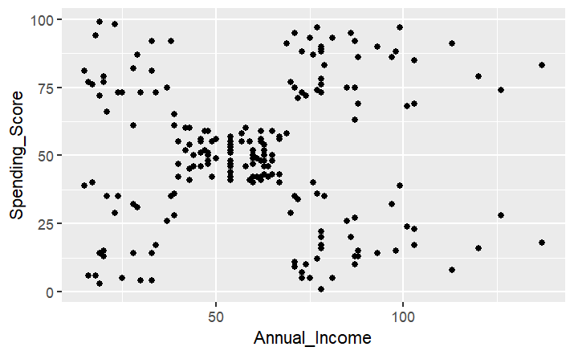

```r
# Draw a scatter plot
ggplot(data, aes(x = Annual_Income, y = Spending_Score) ) + geom_point()
```

3. Apply K-means clustering Initially we need to define a value for K (number of clusters).Since out target is to find 5 customer groups, K = 5.

```r
# Find 5 clusters using K-means clustering
clusters <- kmeans(filtered_data1, 5)
# View cluster details
clusters
```

```
K-means clustering with 5 clusters of sizes 81, 23, 35, 22, 39

Cluster means:
  Annual_Income Spending_Score
1      55.29630       49.51852
2      26.30435       20.91304
3      88.20000       17.11429
4      25.72727       79.36364
5      86.53846       82.12821

Clustering vector:
  [1] 2 4 2 4 2 4 2 4 2 4 2 4 2 4 2 4 2 4 2 4 2 4 2 4 2
 [26] 4 2 4 2 4 2 4 2 4 2 4 2 4 2 4 2 4 2 1 2 4 1 1 1 1
 [51] 1 1 1 1 1 1 1 1 1 1 1 1 1 1 1 1 1 1 1 1 1 1 1 1 1
 [76] 1 1 1 1 1 1 1 1 1 1 1 1 1 1 1 1 1 1 1 1 1 1 1 1 1
[101] 1 1 1 1 1 1 1 1 1 1 1 1 1 1 1 1 1 1 1 1 1 1 1 5 3
[126] 5 1 5 3 5 3 5 1 5 3 5 3 5 3 5 3 5 1 5 3 5 3 5 3 5
[151] 3 5 3 5 3 5 3 5 3 5 3 5 3 5 3 5 3 5 3 5 3 5 3 5 3
[176] 5 3 5 3 5 3 5 3 5 3 5 3 5 3 5 3 5 3 5 3 5 3 5 3 5

Within cluster sum of squares by cluster:
[1]  9875.111  5098.696 12511.143  3519.455 13444.051
 (between_SS / total_SS =  83.5 %)

Available components:

[1] "cluster"      "centers"      "totss"
[4] "withinss"     "tot.withinss" "betweenss"
[7] "size"         "iter"         "ifault"
```

Q1: What can you tell about the customer groups you obtained?

4. Visualise clusters

```r
# Extract cluster indices
cluster_index <- as.factor(clusters$cluster)
# View cluster details
ggplot(filtered_data1, aes(x = Annual_Income, y = Spending_Score, color =
cluster_index)) + geom_point()
```

[output not shown]

Task 5: K-means clustering using more attributes; “Age”, “Annual_Income” and “Spending_Score”.

1. Filter targeted attributes Create a new data frame which only contains the columns “Age”, “Annual_Income” and“Spending_Score”.

```r
# filter data by column name
filtered_data2 <- data[, c("Age", "Annual_Income","Spending_Score")]
```

2. Apply K-means clustering Similarly, as before, we can apply clustering to new data frame (filtered_data2).

```r
# Find 5 clusters using K-means clustering
clusters2 <- kmeans(filtered_data2, 5)
# View cluster details
clusters2
```

[output not shown]

Q2: What can you tell about the customer groups by considering all 3 attributes? c) Visualise clusters Now, our clusters are in 3-dimensional spacewith the dimensions “Age”,“Annual_Income”and “Spending_Score”. Thus, we cannot simply use the above graph generation method. There are methods which helps us to map multidimensional spaces with more than 2dimensions into 2 dimensional spaces for visualisation purpose.

```r
# Visualise clusters in 3 or high dimensional spaces
fviz_cluster(clusters2, data = filtered_data2, geom = c("point"))
```

[output not shown]

6. Overcome initial centroid problem As we discussed in the lecture, having multiple runs is the simplest way which help overcoming initial centroid problem. Just adding 1 argument (nstart) to the function, you can have multiple runs.

```r
# Find 5 clusters using K-means clustering
clusters3 <- kmeans(filtered_data2, 5, nstart = 25)
# View cluster details
clusters3
```

```
K-means clustering with 5 clusters of sizes 79, 39, 23, 23, 36

Cluster means:
       Age Annual_Income Spending_Score
1 43.08861      55.29114       49.56962
2 32.69231      86.53846       82.12821
3 45.21739      26.30435       20.91304
4 25.52174      26.30435       78.56522
5 40.66667      87.75000       17.58333

Clustering vector:
  [1] 3 4 3 4 3 4 3 4 3 4 3 4 3 4 3 4 3 4 3 4 3 4 3 4 3
 [26] 4 3 4 3 4 3 4 3 4 3 4 3 4 3 4 3 4 3 4 3 4 1 1 1 1
 [51] 1 1 1 1 1 1 1 1 1 1 1 1 1 1 1 1 1 1 1 1 1 1 1 1 1
 [76] 1 1 1 1 1 1 1 1 1 1 1 1 1 1 1 1 1 1 1 1 1 1 1 1 1
[101] 1 1 1 1 1 1 1 1 1 1 1 1 1 1 1 1 1 1 1 1 1 1 1 2 5
[126] 2 1 2 5 2 5 2 5 2 5 2 5 2 5 2 5 2 1 2 5 2 5 2 5 2
[151] 5 2 5 2 5 2 5 2 5 2 5 2 5 2 5 2 5 2 5 2 5 2 5 2 5
[176] 2 5 2 5 2 5 2 5 2 5 2 5 2 5 2 5 2 5 2 5 2 5 2 5 2

Within cluster sum of squares by cluster:
[1] 30138.051 13972.359  8948.609  4622.261 17669.500
 (between_SS / total_SS =  75.6 %)

Available components:

[1] "cluster"      "centers"      "totss"
[4] "withinss"     "tot.withinss" "betweenss"
[7] "size"         "iter"         "ifault"
```

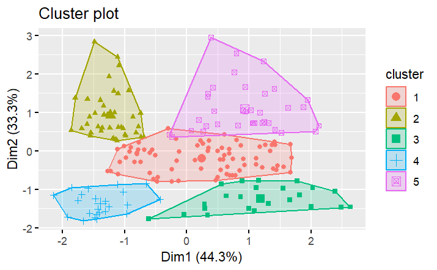

```r
# Visualise clusters in 3 or high dimensional spaces
fviz_cluster(clusters3, data = filtered_data2, geom = c("point"))
```

- Note:
1. nstart = 25 means, you are having 25 random initialisations. Final / resulting clusteringwould be the best one.
2. You want see clear difference in your new clusters compared to previous clusters, if the bestclustering is randomly selected already.